# Decoding Protein-Protein Interactions: A Model Performance Comparison

## ABSTRACT

Protein-protein interactions (PPIs) play a crucial role in various biological processes, influencing cell signaling, metabolic pathways, and disease mechanisms. Understanding and classifying these interactions into positive and negative categories can significantly impact drug discovery and systems biology research. This study explores the classification of PPIs using multiple machine learning models, including Logistic Regression, Decision Tree, Random Forest, and XGBoost. The dataset was sourced from Kaggle, containing separate files for positive and negative protein interactions. The primary objective was to evaluate model performance in distinguishing between these two classes.

The dataset underwent preprocessing, including data normalization, feature selection, and train-test splitting. Logistic Regression, Decision Tree, and Random Forest achieved a perfect classification accuracy of 100%, with precision, recall, and F1-score of 1.00 for both classes. Such performance, however, raises concerns about potential overfitting, suggesting a need for further validation on external datasets. Conversely, the XGBoost model performed poorly, with an accuracy of only 50% and failed to classify negative interactions properly. This study highlights the effectiveness of classical machine learning models in classifying PPIs while underlining the need for robust validation techniques to ensure real-world applicability. Future work should focus on deep learning approaches and feature engineering to enhance classification robustness.

Keywords: Protein-Protein Interactions, Machine Learning, Logistic Regression, Random Forest, Overfitting, XGBoost

## Introduction

1.1 Proteins: The Fundamental Building Blocks of Life Proteins are macromolecules essential for life, performing a vast array of functions within biological systems. These biomolecules are composed of amino acids linked by peptide bonds and are responsible for numerous structural, enzymatic, and regulatory functions in cells (Nelson & Cox, 2021). Proteins are involved in catalyzing biochemical reactions, maintaining cellular structures, transporting molecules, and facilitating communication between cells. They are indispensable in nearly all physiological processes, from metabolism and immunity to growth and development (Berg et al., 2015).

Proteins exhibit remarkable diversity in structure and function, making them crucial for sustaining life. Their role extends beyond basic cellular functions to complex biological processes such as signal transduction, immune responses, and DNA replication. The study of protein interactions, particularly protein-protein interactions (PPIs), has gained significance in biotechnology, molecular biology, and drug discovery, as understanding these interactions provides insights into cellular mechanisms and disease pathology (Alberts et al., 2019).

1.2 Structure and Composition of Proteins Proteins are composed of 20 standard amino acids, each possessing a central carbon atom (α-carbon), an amino group (-NH₂), a carboxyl group (-COOH), and a distinctive side chain (R-group) that determines the amino acid’s properties (Voet & Voet, 2018). The sequence and arrangement of these amino acids dictate the protein’s final structure and function. Protein structures are classified into four levels:

Primary Structure: The linear sequence of amino acids in a polypeptide chain, determined by genetic coding. Secondary Structure: Localized folding patterns, such as α-helices and β-sheets, stabilized by hydrogen bonds. Tertiary Structure: The three-dimensional conformation formed by interactions between secondary structures, including hydrophobic interactions, disulfide bonds, and van der Waals forces. Quaternary Structure: The assembly of multiple polypeptide chains (subunits) into a functional protein complex (Nelson & Cox, 2021). 1.3 Properties of Proteins Proteins exhibit several fundamental properties that define their structure, function, and stability in biological systems:

1.3.1 Solubility and Hydrophobicity The solubility of proteins depends on the nature of their amino acid composition. Hydrophilic proteins dissolve easily in aqueous environments, while hydrophobic proteins tend to aggregate or integrate into lipid membranes. The hydrophobic effect plays a crucial role in protein folding and stability, ensuring that nonpolar amino acid residues remain buried inside the protein structure while polar residues interact with the aqueous environment (Branden & Tooze, 2012).

1.3.2 Denaturation and Stability Proteins are sensitive to changes in temperature, pH, and chemical environments. Denaturation refers to the loss of a protein’s functional three-dimensional structure due to external stressors such as heat, acids, or detergents. Denatured proteins often lose their biological activity, but some can regain functionality through renaturation if the denaturing agent is removed (Nelson & Cox, 2021).

1.3.3 Catalytic Activity One of the most vital functions of proteins is acting as enzymes to catalyze biochemical reactions. Enzymatic proteins lower activation energy, accelerating metabolic processes essential for life. For example, DNA polymerase facilitates DNA replication, while amylase aids in carbohydrate digestion (Berg et al., 2015).

1.3.4 Specificity and Binding Affinity Proteins exhibit a high degree of specificity for their biological targets. This property is crucial for protein-protein interactions, enzyme-substrate recognition, and antigen-antibody interactions. The binding affinity of proteins is determined by molecular complementarity, hydrogen bonding, electrostatic interactions, and van der Waals forces (Voet & Voet, 2018).

1.3.5 Structural and Mechanical Properties Some proteins serve as structural components within cells and tissues. For instance, collagen provides tensile strength to connective tissues, keratin forms protective structures such as hair and nails, and actin and myosin facilitate muscle contraction. These proteins contribute to the mechanical integrity and mobility of organisms (Alberts et al., 2019).

1.3.6 Role in Cellular Communication Proteins are critical in cell signaling and communication. Hormonal proteins such as insulin regulate glucose metabolism, while receptor proteins like G-protein coupled receptors (GPCRs) mediate responses to extracellular signals. These functions are vital for maintaining homeostasis and coordinating cellular activities (Nelson & Cox, 2021).

1.4 Importance of Protein-Protein Interactions (PPIs) Protein-protein interactions are essential for virtually all biological functions, from enzyme-substrate binding to immune system responses. These interactions determine cellular responses, signaling pathways, and metabolic regulation. Disruptions in PPIs have been linked to various diseases, including cancer, neurodegenerative disorders, and infectious diseases (Zhou et al., 2022).

Understanding PPIs helps in drug design and therapeutic development, as targeting specific protein interactions can modulate disease progression. Machine learning models have become powerful tools in identifying and classifying PPIs, providing insights into protein function and interaction networks (Sureja, 2023). This study focuses on classifying positive and negative PPIs using machine learning approaches to enhance our understanding of biological interactions and their implications in biotechnology and medicine.

### Problem Statement

Proteins play a crucial role in biological processes, interacting with each other to regulate cellular functions. Protein-protein interactions (PPIs) are fundamental to many physiological and pathological mechanisms, making their identification and classification essential for advancements in biotechnology, drug discovery, and disease research. However, distinguishing between positive PPIs (functionally relevant interactions) and negative PPIs (non-interacting protein pairs) remains a significant challenge due to the complexity of protein structures and interaction dynamics.

Traditional experimental methods such as yeast two-hybrid screening and co-immunoprecipitation are time-consuming, expensive, and often produce false positives or negatives. As an alternative, machine learning models provide an efficient computational approach to classify PPIs based on large datasets. In this study, a dataset containing positive and negative PPIs was analyzed using machine learning models—Logistic Regression, Decision Tree, Random Forest, and XGBoost—to determine the most effective model for classification.

### library used

pandas is a powerful data manipulation and analysis library in Python. It provides data structures like DataFrame and Series to efficiently handle and manipulate large datasets, and it offers tools for merging, reshaping, selecting, and cleaning data. numpy is a fundamental package for scientific computing in Python. It provides support for large, multi-dimensional arrays and matrices, along with a collection of high-level mathematical functions to operate on these arrays.matplotlib is a widely-used plotting library for Python. pyplot is a module in matplotlib used for creating static, animated, and interactive visualizations in Python.seaborn is a Python data visualization library based on matplotlib. It provides a high-level interface for creating attractive and informative statistical graphics.itertools is a standard Python library providing functions that create iterators for efficient looping. It includes functions for creating permutations, combinations, and Cartesian products.Bio is part of the Biopython library, which provides tools for biological computation. It includes modules for reading and writing sequence data, working with bioinformatics file formats, and conducting various sequence-based analyses.warnings is a Python module used for issuing warning messages. It allows the programmer to control how warnings are displayed and to suppress them if necessary.This module from Biopython's SeqUtils package provides tools for computing various properties of proteins, such as molecular weight, amino acid composition, and hydrophobicity.sklearn.model_selection is part of the Scikit-learn library, providing utilities for splitting datasets into training and test sets, performing cross-validation, and tuning hyperparameters.sklearn.linear_model provides a set of linear models, such as linear regression and logistic regression, used for modeling data with linear relationships.sklearn.tree contains decision tree algorithms used for classification and regression tasks. It includes tools for growing decision trees, pruning them, and visualizing the tree.sklearn.ensemble provides ensemble methods like Random Forests and Gradient Boosting, which combine multiple models to improve performance and accuracy.sklearn.preprocessing provides techniques for scaling, normalizing, and transforming data before using it in machine learning models, such as StandardScaler and MinMaxScaler.xgboost is an optimized gradient boosting library designed for speed and performance. It is used for building decision tree-based models and is highly effective for classification and regression tasks.

```python
import pandas as pd
import numpy as np
import matplotlib.pyplot as plt
import seaborn as sns
import itertools
import Bio
import warnings
from Bio.SeqUtils import ProtParam
warnings.filterwarnings("ignore")
```

### PPI Dataset Overview

This dataset provides a collection of protein-protein interaction (PPI) data, which is essential for understanding how proteins interact with each other to carry out cellular functions. The dataset includes interaction information between proteins from various species, making it useful for exploring biological networks and predicting protein behavior in various conditions.

#### Data Source:

The dataset can be accessed at the following link: [PPI Dataset on Kaggle](https://www.kaggle.com/datasets/spandansureja/ppi-dataset/data)

```python
amino_acids_posi = pd.read_csv(r"C:\Users\manoj\Downloads\Protein Protein Interaction Dataset\positive_protein_sequences.csv")
```

```python
amino_acids_neg = pd.read_csv(r"C:\Users\manoj\Downloads\Protein Protein Interaction Dataset\negative_protein_sequences.csv")
```

```python
amino_acids_posi.head()
amino_acids_posi.head()
```

|  | protein_sequences_1 | protein_sequences_2 |
| --- | --- | --- |
| 0 | MESSKKMDSPGALQTNPPLKLHTDRSAGTPVFVPEQGGYKEKFVKT... | MARPHPWWLCVLGTLVGLSATPAPKSCPERHYWAQGKLCCQMCEPG... |
| 1 | MVMSSYMVNSKYVDPKFPPCEEYLQGGYLGEQGADYYGGGAQGADF... | MAENVVEPGPPSAKRPKLSSPALSASASDGTDFGSLFDLEHDLPDE... |
| 2 | MNRHLWKSQLCEMVQPSGGPAADQDVLGEESPLGKPAMLHLPSEQG... | MEGGRRARVVIESKRNFFLGAFPTPFPAEHVELGRLGDSETAMVPG... |
| 3 | MAPPSTREPRVLSATSATKSDGEMVLPGFPDADSFVKFALGSVVAV... | MLFYSFFKSLVGKDVVVELKNDLSICGTLHSVDQYLNIKLTDISVT... |
| 4 | MQSGPRPPLPAPGLALALTLTMLARLASAASFFGENHLEVPVATAL... | MQTIKCVVVGDGAVGKTCLLISYTTNKFPSEYVPTVFDNYAVTVMI... |

```python
amino_acids_posi.tail()
amino_acids_posi.tail()
```

|  | protein_sequences_1 | protein_sequences_2 |
| --- | --- | --- |
| 36625 | METQFRRGGLGCSPASIKRKKKREDSGDFGLQVSTMFSEDDFQSTE... | MFYGTHFIMSPPTKSKLKRQSQLLSSMLSRTLSYKYRDLDSTFSSL... |
| 36626 | MDAKARNCLLQHREALEKDIKTSYIMDHMISDGFLTISEEEKVRNE... | MSQSNRELVVDFLSYKLSQKGYSWSQFSDVEENRTEAPEGTESEME... |
| 36627 | MSLLCVRVKRAKFQGSPDKFNTYVTLKVQNVKSTTVAVRGDQPSWE... | MADTIFGSGNDQWVCPNDRQLALRAKLQTGWSVHTYQTEKQRRKQH... |
| 36628 | MERRRITSAARRSYVSSGEMMVGGLAPGRRLGPGTRLSLARMPPPL... | MDLHKQWENTETNWHKEKMELLDQFDNERKEWESQWKIMQKKIEEL... |
| 36629 | METPLDVLSRAASLVHADDEKREAALRGEPRMQTLPVASALSSHRT... | MERMSDSADKPIDNDAEGVWSPDIEQSFQEALAIYPPCGRRKIILS... |

```python
amino_acids_neg.head()
amino_acids_neg.head()
```

|  | protein_sequences_1 | protein_sequences_2 |
| --- | --- | --- |
| 0 | MSVEMDSSSFIQFDVPEYSSTVLSQLNELRLQGKLCDIIVHIQGQP... | MGDTFIRHIALLGFEKRFVPSQHYVYMFLVKWQDLSEKVVYRRFTE... |
| 1 | MPITRMRMRPWLEMQINSNQIPGLIWINKEEMIFQIPWKHAAKHGW... | MTMPVNGAHKDADLWSSHDKMLAQPLKDSDVEVYNIIKKESNRQRV... |
| 2 | MLCVRGARLKRELDATATVLANRQDESEQSRKRLIEQSREFKKNTP... | MRLTLLCCTWREERMGEEGSELPVCASCGQRIYDGQYLQALNADWH... |
| 3 | MDALESLLDEVALEGLDGLCLPALWSRLETRVPPFPLPLEPCTQEF... | MERLQKQPLTSPGSVSPSRDSSVPGSPSSIVAKMDNQVLGYKDLAA... |
| 4 | MALSRGLPRELAEAVAGGRVLVVGAGGIGCELLKNLVLTGFSHIDL... | MVVMNSLRVILQASPGKLLWRKFQIPRFMPARPCSLYTCTYKTRNR... |

```python
amino_acids_neg.tail()
amino_acids_neg.tail()
```

|  | protein_sequences_1 | protein_sequences_2 |
| --- | --- | --- |
| 36475 | MERFVVTAPPARNRSKTALYVTPLDRVTEFGGELHEDGGKLFCTSC... | MLGMIKNSLFGSVETWPWQVLSKGDKEEVAYEERACEGGKFATVEV... |
| 36476 | MAAGKSGGSAGEITFLEALARSESKRDGGFKNNWSFDHEEESEGDT... | MSSASGLRRGHPAGGEENMTETDAFYKREMFDPAEKYKMDHRRRGI... |
| 36477 | MQAQQYQQQRRKFAAAFLAFIFILAAVDTAEAGKKEKPEKKVKKSD... | MPRGRKSRRRRNARAAEENRNNRKIQASEASETPMAASVVASTPED... |
| 36478 | MNQPQRMAPVGTDKELSDLLDFSMMFPLPVTNGKGRPASLAGAQFG... | MVPALRYLVGACGRARGRFAGGSPGACGFASGRPRPLCGGSRSAST... |
| 36479 | MSATGPISNYYVDSLISHDNEDLLASRFPATGAHPAAARPSGLVPD... | MSDYENDDECWSVLEGFRVTLTSVIDPSRITPYLRQCKVLNPDDEE... |

```python
amino_acids_posi.columns
```

```
Index(['protein_sequences_1', 'protein_sequences_2'], dtype='object')
```

```python
amino_acids_neg.columns
```

```
Index(['protein_sequences_1', 'protein_sequences_2'], dtype='object')
```

```python
amino_acids_posi["proteins"] = 1
amino_acids_neg ["proteins"] = 0
protein_df = pd.concat([amino_acids_posi,amino_acids_neg ], axis=0, ignore_index=True)
```

```python
protein_df
```

|  | protein_sequences_1 | protein_sequences_2 | proteins |
| --- | --- | --- | --- |
| 0 | MESSKKMDSPGALQTNPPLKLHTDRSAGTPVFVPEQGGYKEKFVKT... | MARPHPWWLCVLGTLVGLSATPAPKSCPERHYWAQGKLCCQMCEPG... | 1 |
| 1 | MVMSSYMVNSKYVDPKFPPCEEYLQGGYLGEQGADYYGGGAQGADF... | MAENVVEPGPPSAKRPKLSSPALSASASDGTDFGSLFDLEHDLPDE... | 1 |
| 2 | MNRHLWKSQLCEMVQPSGGPAADQDVLGEESPLGKPAMLHLPSEQG... | MEGGRRARVVIESKRNFFLGAFPTPFPAEHVELGRLGDSETAMVPG... | 1 |
| 3 | MAPPSTREPRVLSATSATKSDGEMVLPGFPDADSFVKFALGSVVAV... | MLFYSFFKSLVGKDVVVELKNDLSICGTLHSVDQYLNIKLTDISVT... | 1 |
| 4 | MQSGPRPPLPAPGLALALTLTMLARLASAASFFGENHLEVPVATAL... | MQTIKCVVVGDGAVGKTCLLISYTTNKFPSEYVPTVFDNYAVTVMI... | 1 |
| ... | ... | ... | ... |
| 73105 | MERFVVTAPPARNRSKTALYVTPLDRVTEFGGELHEDGGKLFCTSC... | MLGMIKNSLFGSVETWPWQVLSKGDKEEVAYEERACEGGKFATVEV... | 0 |
| 73106 | MAAGKSGGSAGEITFLEALARSESKRDGGFKNNWSFDHEEESEGDT... | MSSASGLRRGHPAGGEENMTETDAFYKREMFDPAEKYKMDHRRRGI... | 0 |
| 73107 | MQAQQYQQQRRKFAAAFLAFIFILAAVDTAEAGKKEKPEKKVKKSD... | MPRGRKSRRRRNARAAEENRNNRKIQASEASETPMAASVVASTPED... | 0 |
| 73108 | MNQPQRMAPVGTDKELSDLLDFSMMFPLPVTNGKGRPASLAGAQFG... | MVPALRYLVGACGRARGRFAGGSPGACGFASGRPRPLCGGSRSAST... | 0 |
| 73109 | MSATGPISNYYVDSLISHDNEDLLASRFPATGAHPAAARPSGLVPD... | MSDYENDDECWSVLEGFRVTLTSVIDPSRITPYLRQCKVLNPDDEE... | 0 |

73110 rows × 3 columns

#### * Since both datasets have the same column names , concatenate them vertically

#### * axis = 0 tells adding more rows below via axis = 1 tells adding columns

#### *ignore_index=True shows Resets index after merging (If you don’t need to keep the original row indices)

#### *ignore_index=False shows Keeps the original index values (If you want to retain original index information)

```python
protein_df.shape
protein_df.shape[0]
```

```
73110
```

##### no.of rows = 73110

```python
protein_df.shape[1]
```

```
3
```

##### no.of columns = 3

## exploratory data analysis (EDA)

### There are 20 amino acids that make up proteins. These amino acids are used by all living things to make proteins.

#### Essential amino acids

##### histidine, isoleucine, leucine, lysine, methionine, phenylalanine, threonine, tryptophan, and valine.

#### Non-essential amino acids.

##### The other 11 amino acids that the body can synthesize Alanine,Arginine Asparagine, Aspartic acid ,Cysteine, Glutamic acid,Glutamine,Glycine,Proline,Serine,Tyrosine.

```python
amino_acids = {"A", "C", "D", "E", "F", "G", "H", "I", "K", "L", "M", "N", "P",
               "Q", "R", "S", "T", "V", "W", "Y"}
```

# Standard Amino Acids

| Single-Letter Code | Amino Acid Name |
| --- | --- |
| **A** | Alanine |
| **C** | Cysteine |
| **D** | Aspartic Acid |
| **E** | Glutamic Acid |
| **F** | Phenylalanine |
| **G** | Glycine |
| **H** | Histidine |
| **I** | Isoleucine |
| **K** | Lysine |
| **L** | Leucine |
| **M** | Methionine |
| **N** | Asparagine |
| **P** | Proline |
| **Q** | Glutamine |
| **R** | Arginine |
| **S** | Serine |
| **T** | Threonine |
| **V** | Valine |
| **W** | Tryptophan |
| **Y** | Tyrosine |

```python
def count_non_standard(sequence):
    """Check for non-standard amino acids in a protein sequence."""
    sequence_set = set(sequence)
    non_standard_amino_acids = sequence_set - amino_acids
    if non_standard_amino_acids:
        print(f"Non-standard amino acids in sequence: {non_standard_amino_acids}")
    return len(non_standard_amino_acids) > 0
```

#### This function checks if a given protein sequence contains any non-standard amino acids, which are amino acids that are not part of the 20 standard ones. It first converts the sequence into a set, allowing it to identify all unique amino acids present. Then, it compares this set with the standard amino acids to find any that do not belong to the standard list. If any non-standard amino acids are found, they are printed. Finally, the function returns True if non-standard amino acids are present, otherwise, it returns False

```python
non_standard_count = sum(count_non_standard(seq) for seq in protein_df['protein_sequences_1'])

print("Number of sequences with non-standard amino acids:", non_standard_count)
```

```
Non-standard amino acids in sequence: {'U'}
Non-standard amino acids in sequence: {'U'}
Non-standard amino acids in sequence: {'U'}
Number of sequences with non-standard amino acids: 3
```

```python
count_non_standard2 = sum(count_non_standard(seq) for seq in protein_df['protein_sequences_2'])

print("Number of sequences with non-standard amino acids:", count_non_standard2)
```

[output not shown]

[output cut: 108 more lines]

```
Non-standard amino acids in sequence: {'U'}
Non-standard amino acids in sequence: {'U'}
Non-standard amino acids in sequence: {'U'}
Non-standard amino acids in sequence: {'U'}
Non-standard amino acids in sequence: {'U'}
Non-standard amino acids in sequence: {'U'}
Non-standard amino acids in sequence: {'U'}
Non-standard amino acids in sequence: {'U'}
Non-standard amino acids in sequence: {'U'}
Non-standard amino acids in sequence: {'U'}
Non-standard amino acids in sequence: {'U'}
Non-standard amino acids in sequence: {'U'}
Non-standard amino acids in sequence: {'U'}
Non-standard amino acids in sequence: {'U'}
Number of sequences with non-standard amino acids: 162
```

### The amino acid represented by "U" is Selenocysteine.Selenocysteine is a non-standard amino acid that contains selenium instead of sulfur. It's the 21st amino acid and is encoded by the codon UGA, which normally functions as a stop codon.It's chemically similar to cysteine, but it provides a selective advantage for particular redox enzymatic functions.

```python
# Define amino acid properties
hydrophobicity = {
    'A': 1.8, 'C': 2.5, 'D': -3.5, 'E': -3.5, 'F': 2.8, 'G': -0.4,
    'H': -3.2, 'I': 4.5, 'K': -3.9, 'L': 3.8, 'M': 1.9, 'N': -3.5,
    'P': -1.6, 'Q': -3.5, 'R': -4.5, 'S': -0.8, 'T': -0.7, 'V': 4.2,
    'W': -0.9, 'Y': -1.3
}

positive_charged = {'R', 'K', 'H'}
negative_charged = {'D', 'E'}
aliphatic_residues = {'A', 'V', 'I', 'L'}
hydrogen_bond_donors_acceptors = {'S', 'T', 'Y', 'H'}
ph_sensitive_residues = {'H', 'D', 'E', 'K', 'R'}

# Function to compute features
def compute_features(seq1, seq2):
    if not seq1 or not seq2:
        return [0] * 13  # Return zeroed features if any sequence is missing

    # Sequence length difference
    seq_length_diff = abs(len(seq1) - len(seq2))

    # Average hydrophobicity
    avg_hydro = (sum(hydrophobicity.get(aa, 0) for aa in seq1) / len(seq1) +
                 sum(hydrophobicity.get(aa, 0) for aa in seq2) / len(seq2)) / 2

    # Charge polarity ratio
    pos1 = sum(1 for aa in seq1 if aa in positive_charged)
    neg1 = sum(1 for aa in seq1 if aa in negative_charged)
    pos2 = sum(1 for aa in seq2 if aa in positive_charged)
    neg2 = sum(1 for aa in seq2 if aa in negative_charged)
    charge_ratio = (pos1 + pos2) / (neg1 + neg2 + 1e-6)  # Avoid division by zero

    # Aliphatic index
    aliphatic_index = (sum(1 for aa in seq1 if aa in aliphatic_residues) +
                       sum(1 for aa in seq2 if aa in aliphatic_residues)) / (len(seq1) + len(seq2) + 1e-6)

    # Sequence similarity score
    min_length = min(len(seq1), len(seq2))
    similarity_score = sum(1 for i in range(min_length) if seq1[i] == seq2[i]) / (min_length + 1e-6)

    # Hydrogen bond donor/acceptor ratio
    hbond_ratio = (sum(1 for aa in seq1 if aa in hydrogen_bond_donors_acceptors) +
                   sum(1 for aa in seq2 if aa in hydrogen_bond_donors_acceptors)) / (len(seq1) + len(seq2) + 1e-6)

    # Cysteine count
    cys_count = seq1.count('C') + seq2.count('C')

    # Amino acid diversity score
    diversity_score = len(set(seq1 + seq2))

    # Average molecular weight
    mw1 = ProtParam.ProteinAnalysis(seq1).molecular_weight() / len(seq1)
    mw2 = ProtParam.ProteinAnalysis(seq2).molecular_weight() / len(seq2)
    avg_molecular_weight = (mw1 + mw2) / 2

    # pH stability index
    ph_sensitive_count = sum(1 for aa in seq1 if aa in ph_sensitive_residues) + \
                         sum(1 for aa in seq2 if aa in ph_sensitive_residues)

    # Aromaticity feature
    aromaticity = (ProtParam.ProteinAnalysis(seq1).aromaticity() +
                   ProtParam.ProteinAnalysis(seq2).aromaticity()) / 2

    # Secondary structure percentages (Helix, Turn, Sheet)
    sec_struct1 = ProtParam.ProteinAnalysis(seq1).secondary_structure_fraction()
    sec_struct2 = ProtParam.ProteinAnalysis(seq2).secondary_structure_fraction()
    helix_percent = (sec_struct1[0] + sec_struct2[0]) / 2
    turn_percent = (sec_struct1[1] + sec_struct2[1]) / 2
    sheet_percent = (sec_struct1[2] + sec_struct2[2]) / 2

    return [seq_length_diff, avg_hydro, charge_ratio, aliphatic_index, similarity_score,
            hbond_ratio, cys_count, diversity_score, avg_molecular_weight, ph_sensitive_count,
            aromaticity, helix_percent, turn_percent, sheet_percent]

# Apply the function to the dataset
feature_columns = ["Sequence_Length_Difference", "Average_Hydrophobicity", "Charge_Polarity_Ratio",
                   "Aliphatic_Index", "Sequence_Similarity_Score", "Hydrogen_Bond_Ratio", "Cysteine_Count",
                   "Amino_Acid_Diversity", "Avg_Molecular_Weight", "pH_Stability_Index",
                   "Aromaticity", "Helix_Percentage", "Turn_Percentage", "Sheet_Percentage"]
# Compute features for each row
protein_df[feature_columns] = protein_df.apply(
    lambda row: pd.Series(compute_features(row["protein_sequences_1"], row["protein_sequences_2"])), axis=1
)

# Adding sequence stretch
protein_df["protein1_stretch"] = protein_df["protein_sequences_1"].str.len()
protein_df["protein2_stretch"] = protein_df["protein_sequences_2"].str.len()

# Display the updated dataframe
print(protein_df.head())
```

```
                                 protein_sequences_1  \
0  MESSKKMDSPGALQTNPPLKLHTDRSAGTPVFVPEQGGYKEKFVKT...
1  MVMSSYMVNSKYVDPKFPPCEEYLQGGYLGEQGADYYGGGAQGADF...
2  MNRHLWKSQLCEMVQPSGGPAADQDVLGEESPLGKPAMLHLPSEQG...
3  MAPPSTREPRVLSATSATKSDGEMVLPGFPDADSFVKFALGSVVAV...
4  MQSGPRPPLPAPGLALALTLTMLARLASAASFFGENHLEVPVATAL...

                                 protein_sequences_2  proteins  \
0  MARPHPWWLCVLGTLVGLSATPAPKSCPERHYWAQGKLCCQMCEPG...         1
1  MAENVVEPGPPSAKRPKLSSPALSASASDGTDFGSLFDLEHDLPDE...         1
2  MEGGRRARVVIESKRNFFLGAFPTPFPAEHVELGRLGDSETAMVPG...         1
3  MLFYSFFKSLVGKDVVVELKNDLSICGTLHSVDQYLNIKLTDISVT...         1
4  MQTIKCVVVGDGAVGKTCLLISYTTNKFPSEYVPTVFDNYAVTVMI...         1

   Sequence_Length_Difference  Average_Hydrophobicity  Charge_Polarity_Ratio  \
```

[output cut: 33 more lines]

```python
protein_df.head()
```

|  | protein_sequences_1 | protein_sequences_2 | proteins | Sequence_Length_Difference | Average_Hydrophobicity | Charge_Polarity_Ratio | Aliphatic_Index | Sequence_Similarity_Score | Hydrogen_Bond_Ratio | Cysteine_Count | Amino_Acid_Diversity | Avg_Molecular_Weight | pH_Stability_Index | Aromaticity | Helix_Percentage | Turn_Percentage | Sheet_Percentage | protein1_stretch | protein2_stretch |
| --- | --- | --- | --- | --- | --- | --- | --- | --- | --- | --- | --- | --- | --- | --- | --- | --- | --- | --- | --- |
| 0 | MESSKKMDSPGALQTNPPLKLHTDRSAGTPVFVPEQGGYKEKFVKT... | MARPHPWWLCVLGTLVGLSATPAPKSCPERHYWAQGKLCCQMCEPG... | 1 | 308.0 | -0.486667 | 1.408163 | 0.240338 | 0.053846 | 0.194444 | 49.0 | 20.0 | 112.838286 | 236.0 | 0.067186 | 0.303629 | 0.279076 | 0.290588 | 568 | 260 |
| 1 | MVMSSYMVNSKYVDPKFPPCEEYLQGGYLGEQGADYYGGGAQGADF... | MAENVVEPGPPSAKRPKLSSPALSASASDGTDFGSLFDLEHDLPDE... | 1 | 2159.0 | -0.795597 | 1.595960 | 0.208692 | 0.062745 | 0.182840 | 55.0 | 20.0 | 109.390215 | 514.0 | 0.066018 | 0.265286 | 0.371210 | 0.242115 | 255 | 2414 |
| 2 | MNRHLWKSQLCEMVQPSGGPAADQDVLGEESPLGKPAMLHLPSEQG... | MEGGRRARVVIESKRNFFLGAFPTPFPAEHVELGRLGDSETAMVPG... | 1 | 119.0 | -0.679034 | 0.925000 | 0.266458 | 0.081146 | 0.142111 | 24.0 | 20.0 | 114.981923 | 308.0 | 0.057335 | 0.399857 | 0.230763 | 0.284633 | 419 | 538 |
| 3 | MAPPSTREPRVLSATSATKSDGEMVLPGFPDADSFVKFALGSVVAV... | MLFYSFFKSLVGKDVVVELKNDLSICGTLHSVDQYLNIKLTDISVT... | 1 | 790.0 | -0.359423 | 1.238095 | 0.272449 | 0.084211 | 0.161224 | 16.0 | 20.0 | 113.989214 | 282.0 | 0.083348 | 0.330211 | 0.263039 | 0.362890 | 885 | 95 |
| 4 | MQSGPRPPLPAPGLALALTLTMLARLASAASFFGENHLEVPVATAL... | MQTIKCVVVGDGAVGKTCLLISYTTNKFPSEYVPTVFDNYAVTVMI... | 1 | 2131.0 | -0.157130 | 0.950178 | 0.322324 | 0.083770 | 0.179467 | 18.0 | 20.0 | 109.597951 | 548.0 | 0.074831 | 0.314328 | 0.282699 | 0.381837 | 2322 | 191 |

```python
protein_df.columns
```

```
Index(['protein_sequences_1', 'protein_sequences_2', 'proteins',
       'Sequence_Length_Difference', 'Average_Hydrophobicity',
       'Charge_Polarity_Ratio', 'Aliphatic_Index', 'Sequence_Similarity_Score',
       'Hydrogen_Bond_Ratio', 'Cysteine_Count', 'Amino_Acid_Diversity',
       'Avg_Molecular_Weight', 'pH_Stability_Index', 'Aromaticity',
       'Helix_Percentage', 'Turn_Percentage', 'Sheet_Percentage',
       'protein1_stretch', 'protein2_stretch'],
      dtype='object')
```

```python
from Bio.SeqUtils.ProtParam import ProteinAnalysis
```

```python
def aa_comp(seq):
    amino_acid_composition = {}
    amino_acids = list("ACDEFGHIKLMNPQRSTVWYU")  # Standard amino acids + Selenocysteine (U)

    for aa in amino_acids:
        amino_acid_composition[aa] = round(float(seq.count(aa)) / len(seq) * 100, 3)

    return amino_acid_composition

protein_df["aa_composition"] = protein_df["protein_sequences_1"].apply(aa_comp)
protein_df["aa_composition"] = protein_df["protein_sequences_2"].apply(aa_comp)

print(protein_df.head())
```

```
                                 protein_sequences_1  \
0  MESSKKMDSPGALQTNPPLKLHTDRSAGTPVFVPEQGGYKEKFVKT...
1  MVMSSYMVNSKYVDPKFPPCEEYLQGGYLGEQGADYYGGGAQGADF...
2  MNRHLWKSQLCEMVQPSGGPAADQDVLGEESPLGKPAMLHLPSEQG...
3  MAPPSTREPRVLSATSATKSDGEMVLPGFPDADSFVKFALGSVVAV...
4  MQSGPRPPLPAPGLALALTLTMLARLASAASFFGENHLEVPVATAL...

                                 protein_sequences_2  proteins  \
0  MARPHPWWLCVLGTLVGLSATPAPKSCPERHYWAQGKLCCQMCEPG...         1
1  MAENVVEPGPPSAKRPKLSSPALSASASDGTDFGSLFDLEHDLPDE...         1
2  MEGGRRARVVIESKRNFFLGAFPTPFPAEHVELGRLGDSETAMVPG...         1
3  MLFYSFFKSLVGKDVVVELKNDLSICGTLHSVDQYLNIKLTDISVT...         1
4  MQTIKCVVVGDGAVGKTCLLISYTTNKFPSEYVPTVFDNYAVTVMI...         1

   Sequence_Length_Difference  Average_Hydrophobicity  Charge_Polarity_Ratio  \
```

[output cut: 40 more lines]

```python
protein_df.describe()
```

|  | proteins | Sequence_Length_Difference | Average_Hydrophobicity | Charge_Polarity_Ratio | Aliphatic_Index | Sequence_Similarity_Score | Hydrogen_Bond_Ratio | Cysteine_Count | Amino_Acid_Diversity | Avg_Molecular_Weight | pH_Stability_Index | Aromaticity | Helix_Percentage | Turn_Percentage | Sheet_Percentage | protein1_stretch | protein2_stretch |
| --- | --- | --- | --- | --- | --- | --- | --- | --- | --- | --- | --- | --- | --- | --- | --- | --- | --- |
| count | 73110.000000 | 73110.000000 | 73110.000000 | 73110.000000 | 73110.000000 | 73110.000000 | 73110.000000 | 73110.000000 | 73110.000000 | 73110.000000 | 73110.000000 | 73110.000000 | 73110.000000 | 73110.000000 | 73110.000000 | 73110.000000 | 73110.000000 |
| mean | 0.501026 | 468.117262 | -0.475682 | 1.193942 | 0.266040 | 0.064822 | 0.183688 | 24.453919 | 19.992135 | 111.560147 | 323.233990 | 0.073374 | 0.324975 | 0.296839 | 0.319310 | 622.640405 | 582.975831 |
| std | 0.500002 | 799.562678 | 0.229246 | 0.288368 | 0.032653 | 0.024364 | 0.025578 | 26.926299 | 0.118377 | 2.373778 | 274.832025 | 0.017625 | 0.037174 | 0.036875 | 0.038111 | 697.028588 | 652.549446 |
| min | 0.000000 | 0.000000 | -1.800824 | 0.316901 | 0.051839 | 0.007634 | 0.059776 | 0.000000 | 14.000000 | 94.176690 | 11.000000 | 0.000000 | 0.099046 | 0.112593 | 0.072222 | 24.000000 | 24.000000 |
| 25% | 0.000000 | 121.000000 | -0.604008 | 1.033898 | 0.245877 | 0.053872 | 0.167482 | 11.000000 | 20.000000 | 110.128232 | 183.000000 | 0.061483 | 0.301975 | 0.272035 | 0.296068 | 305.000000 | 274.000000 |
| 50% | 1.000000 | 278.000000 | -0.466046 | 1.150697 | 0.266931 | 0.062857 | 0.182630 | 18.000000 | 20.000000 | 111.755537 | 265.000000 | 0.073127 | 0.323910 | 0.293637 | 0.321130 | 465.000000 | 432.000000 |
| 75% | 1.000000 | 564.000000 | -0.336713 | 1.298104 | 0.287009 | 0.072874 | 0.198770 | 30.000000 | 20.000000 | 113.173274 | 390.750000 | 0.084853 | 0.346667 | 0.318660 | 0.344223 | 743.000000 | 708.000000 |
| max | 1.000000 | 33274.000000 | 0.949566 | 9.666666 | 0.446602 | 1.000000 | 0.403769 | 725.000000 | 21.000000 | 127.131393 | 11961.000000 | 0.183673 | 0.593310 | 0.571103 | 0.579094 | 33423.000000 | 33423.000000 |

```python
protein_df.head()
```

|  | protein_sequences_1 | protein_sequences_2 | proteins | Sequence_Length_Difference | Average_Hydrophobicity | Charge_Polarity_Ratio | Aliphatic_Index | Sequence_Similarity_Score | Hydrogen_Bond_Ratio | Cysteine_Count | Amino_Acid_Diversity | Avg_Molecular_Weight | pH_Stability_Index | Aromaticity | Helix_Percentage | Turn_Percentage | Sheet_Percentage | protein1_stretch | protein2_stretch | aa_composition |
| --- | --- | --- | --- | --- | --- | --- | --- | --- | --- | --- | --- | --- | --- | --- | --- | --- | --- | --- | --- | --- |
| 0 | MESSKKMDSPGALQTNPPLKLHTDRSAGTPVFVPEQGGYKEKFVKT... | MARPHPWWLCVLGTLVGLSATPAPKSCPERHYWAQGKLCCQMCEPG... | 1 | 308.0 | -0.486667 | 1.408163 | 0.240338 | 0.053846 | 0.194444 | 49.0 | 20.0 | 112.838286 | 236.0 | 0.067186 | 0.303629 | 0.279076 | 0.290588 | 568 | 260 | {'A': 7.308, 'C': 8.077, 'D': 3.462, 'E': 6.15... |
| 1 | MVMSSYMVNSKYVDPKFPPCEEYLQGGYLGEQGADYYGGGAQGADF... | MAENVVEPGPPSAKRPKLSSPALSASASDGTDFGSLFDLEHDLPDE... | 1 | 2159.0 | -0.795597 | 1.595960 | 0.208692 | 0.062745 | 0.182840 | 55.0 | 20.0 | 109.390215 | 514.0 | 0.066018 | 0.265286 | 0.371210 | 0.242115 | 255 | 2414 | {'A': 6.297, 'C': 2.113, 'D': 3.19, 'E': 4.184... |
| 2 | MNRHLWKSQLCEMVQPSGGPAADQDVLGEESPLGKPAMLHLPSEQG... | MEGGRRARVVIESKRNFFLGAFPTPFPAEHVELGRLGDSETAMVPG... | 1 | 119.0 | -0.679034 | 0.925000 | 0.266458 | 0.081146 | 0.142111 | 24.0 | 20.0 | 114.981923 | 308.0 | 0.057335 | 0.399857 | 0.230763 | 0.284633 | 419 | 538 | {'A': 3.717, 'C': 2.416, 'D': 6.877, 'E': 9.29... |
| 3 | MAPPSTREPRVLSATSATKSDGEMVLPGFPDADSFVKFALGSVVAV... | MLFYSFFKSLVGKDVVVELKNDLSICGTLHSVDQYLNIKLTDISVT... | 1 | 790.0 | -0.359423 | 1.238095 | 0.272449 | 0.084211 | 0.161224 | 16.0 | 20.0 | 113.989214 | 282.0 | 0.083348 | 0.330211 | 0.263039 | 0.362890 | 885 | 95 | {'A': 4.211, 'C': 2.105, 'D': 8.421, 'E': 4.21... |
| 4 | MQSGPRPPLPAPGLALALTLTMLARLASAASFFGENHLEVPVATAL... | MQTIKCVVVGDGAVGKTCLLISYTTNKFPSEYVPTVFDNYAVTVMI... | 1 | 2131.0 | -0.157130 | 0.950178 | 0.322324 | 0.083770 | 0.179467 | 18.0 | 20.0 | 109.597951 | 548.0 | 0.074831 | 0.314328 | 0.282699 | 0.381837 | 2322 | 191 | {'A': 5.759, 'C': 3.141, 'D': 5.759, 'E': 6.80... |

```python
protein_df.info()
```

```
<class 'pandas.core.frame.DataFrame'>
RangeIndex: 73110 entries, 0 to 73109
Data columns (total 20 columns):
 #   Column                      Non-Null Count  Dtype
---  ------                      --------------  -----
 0   protein_sequences_1         73110 non-null  object
 1   protein_sequences_2         73110 non-null  object
 2   proteins                    73110 non-null  int64
 3   Sequence_Length_Difference  73110 non-null  float64
 4   Average_Hydrophobicity      73110 non-null  float64
 5   Charge_Polarity_Ratio       73110 non-null  float64
 6   Aliphatic_Index             73110 non-null  float64
 7   Sequence_Similarity_Score   73110 non-null  float64
 8   Hydrogen_Bond_Ratio         73110 non-null  float64
 9   Cysteine_Count              73110 non-null  float64
 10  Amino_Acid_Diversity        73110 non-null  float64
 11  Avg_Molecular_Weight        73110 non-null  float64
 12  pH_Stability_Index          73110 non-null  float64
 13  Aromaticity                 73110 non-null  float64
 14  Helix_Percentage            73110 non-null  float64
 15  Turn_Percentage             73110 non-null  float64
 16  Sheet_Percentage            73110 non-null  float64
 17  protein1_stretch            73110 non-null  int64
 18  protein2_stretch            73110 non-null  int64
 19  aa_composition              73110 non-null  object
dtypes: float64(14), int64(3), object(3)
memory usage: 11.2+ MB
```

```python
protein_df.columns
```

```
Index(['protein_sequences_1', 'protein_sequences_2', 'proteins',
       'Sequence_Length_Difference', 'Average_Hydrophobicity',
       'Charge_Polarity_Ratio', 'Aliphatic_Index', 'Sequence_Similarity_Score',
       'Hydrogen_Bond_Ratio', 'Cysteine_Count', 'Amino_Acid_Diversity',
       'Avg_Molecular_Weight', 'pH_Stability_Index', 'Aromaticity',
       'Helix_Percentage', 'Turn_Percentage', 'Sheet_Percentage',
       'protein1_stretch', 'protein2_stretch', 'aa_composition'],
      dtype='object')
```

```python
cols = protein_df.columns.tolist()
cols.remove('protein_sequences_1')
cols.remove('protein_sequences_2')
cols.remove('proteins')
```

```python
protein_df.columns
```

```
Index(['protein_sequences_1', 'protein_sequences_2', 'proteins',
       'Sequence_Length_Difference', 'Average_Hydrophobicity',
       'Charge_Polarity_Ratio', 'Aliphatic_Index', 'Sequence_Similarity_Score',
       'Hydrogen_Bond_Ratio', 'Cysteine_Count', 'Amino_Acid_Diversity',
       'Avg_Molecular_Weight', 'pH_Stability_Index', 'Aromaticity',
       'Helix_Percentage', 'Turn_Percentage', 'Sheet_Percentage',
       'protein1_stretch', 'protein2_stretch', 'aa_composition'],
      dtype='object')
```

## DATA VISUALIZATION

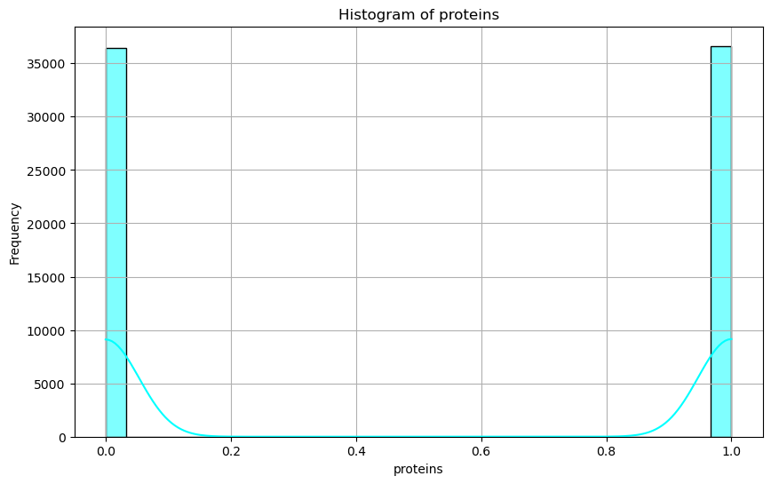

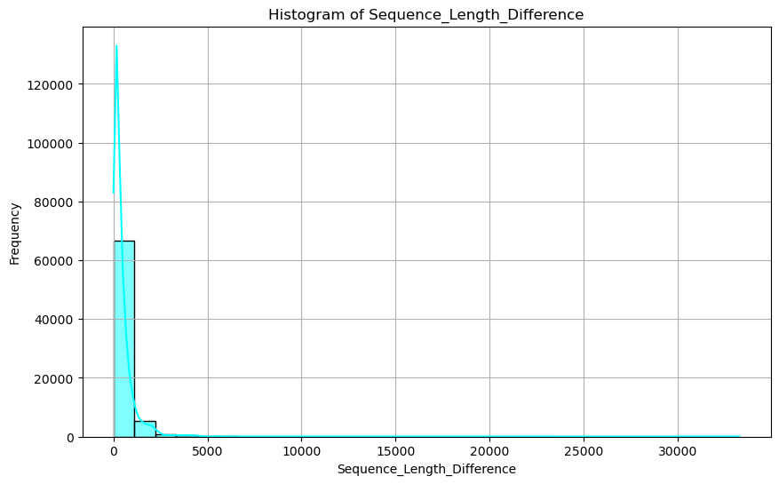

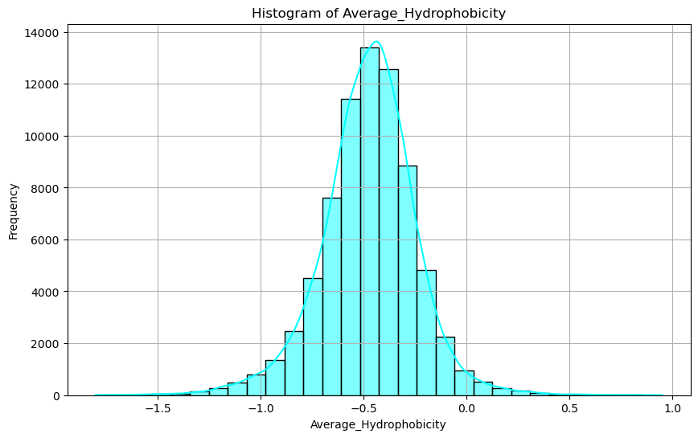

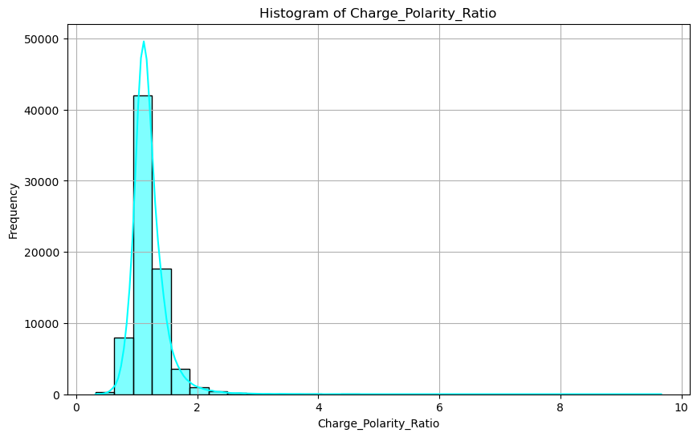

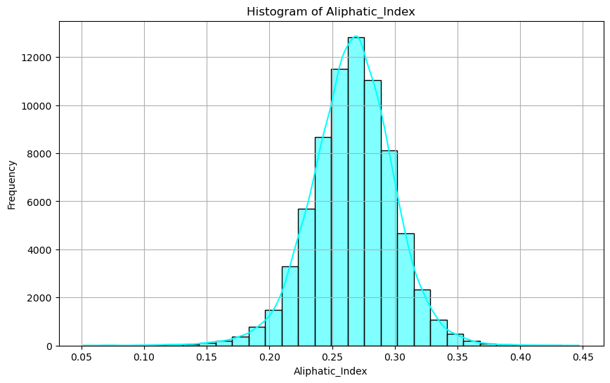

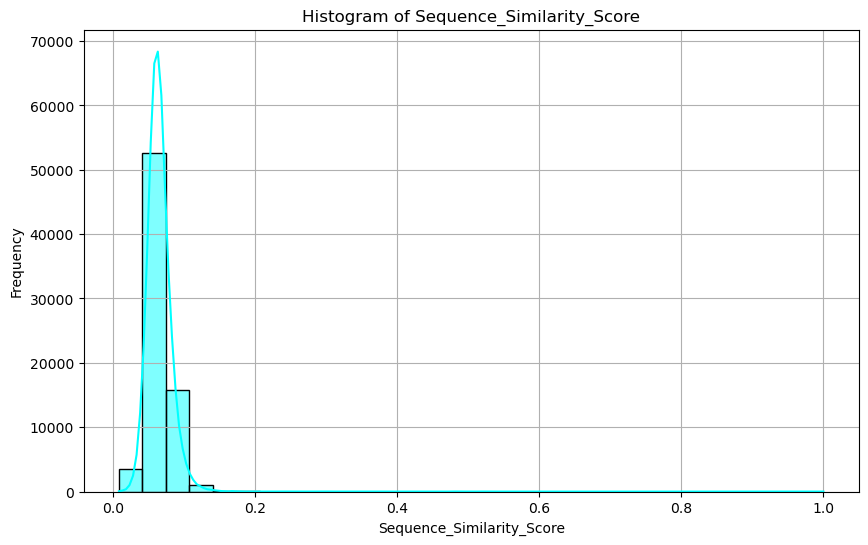

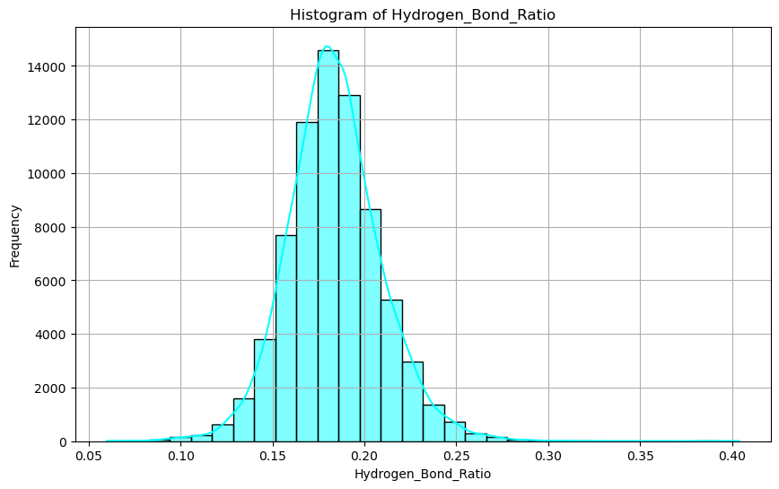

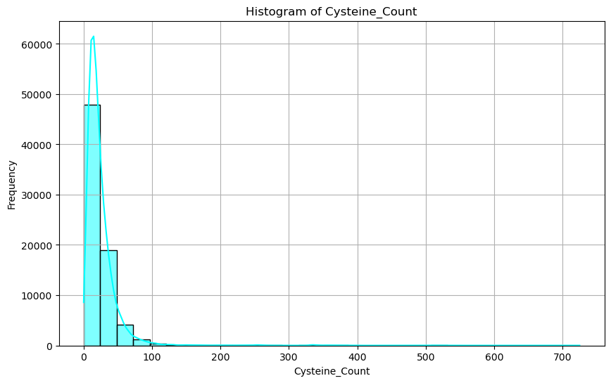

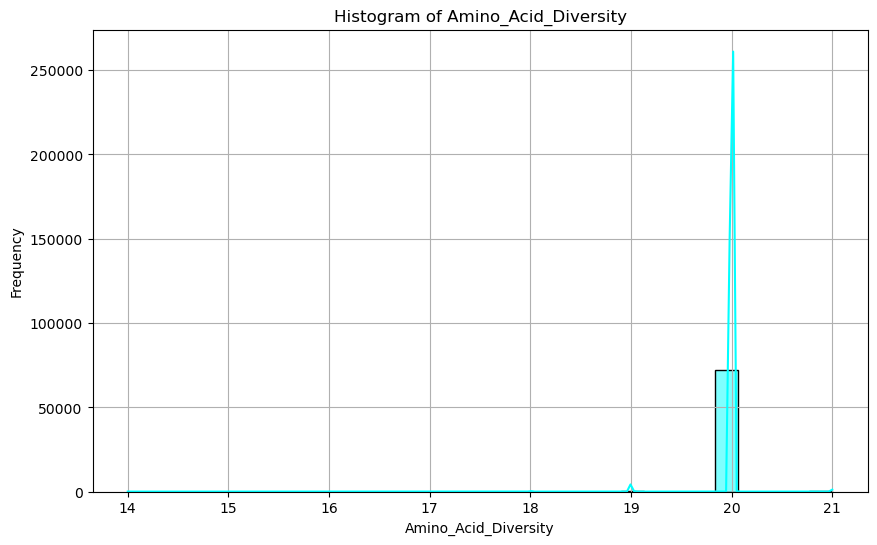

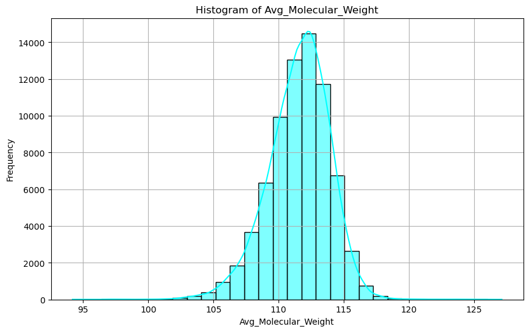

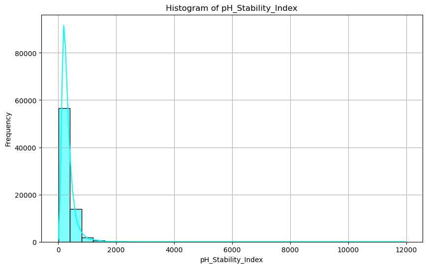

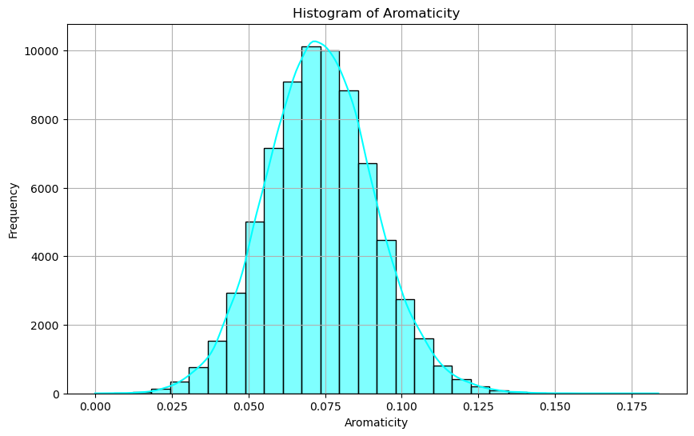

[5 more figures not shown]

```python
Num_Col = protein_df.select_dtypes(include=['int64', 'float64']).columns
for col in Num_Col:
    plt.figure(figsize=(10, 6))
    sns.histplot(protein_df[col], bins=30, kde=True, color='Cyan')
    plt.title(f'Histogram of {col}')
    plt.xlabel(col)
    plt.ylabel('Frequency')
    plt.grid(True)
    plt.show()
```

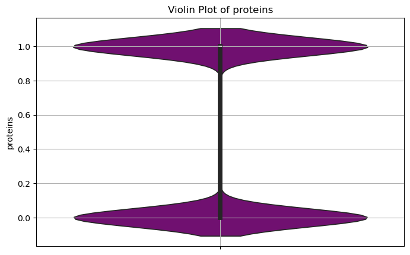

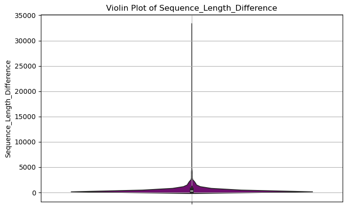

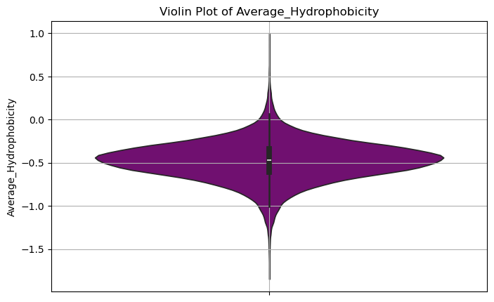

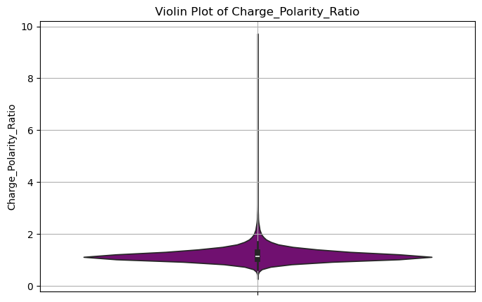

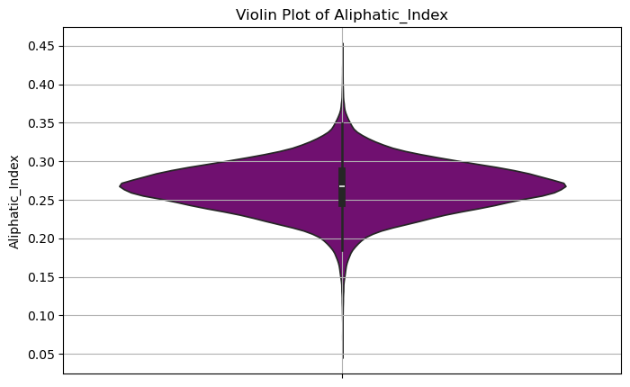

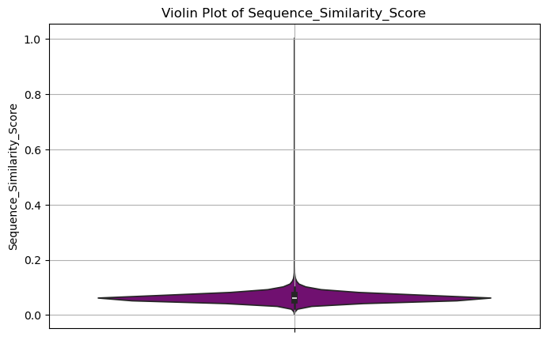

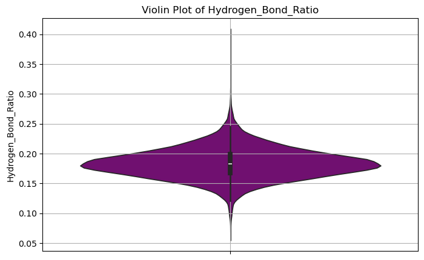

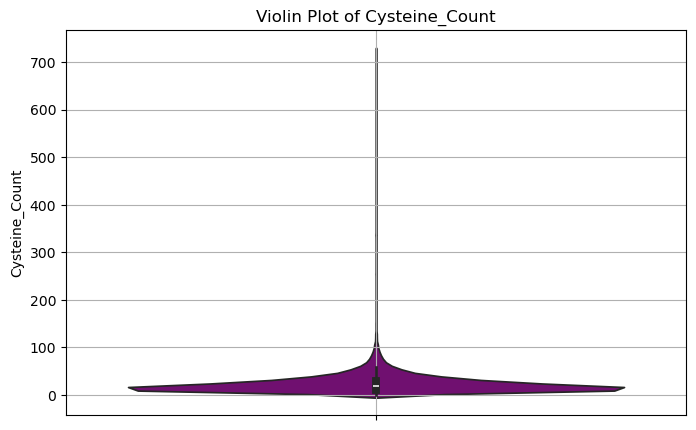

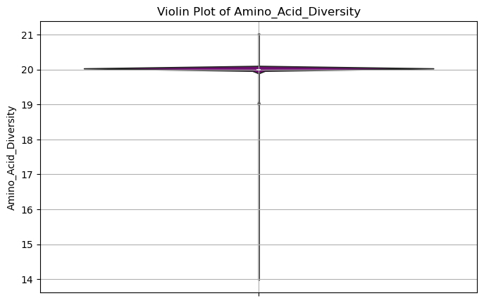

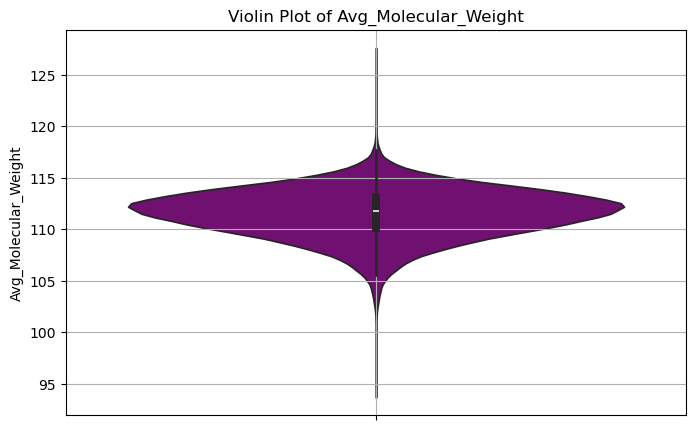

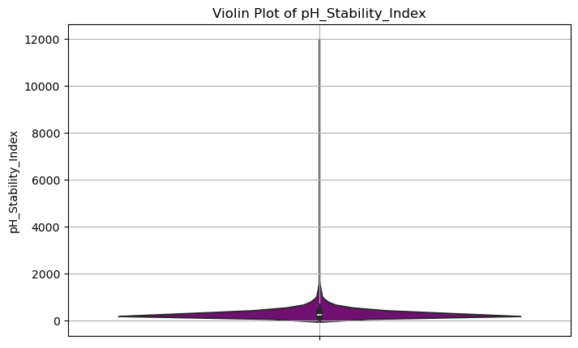

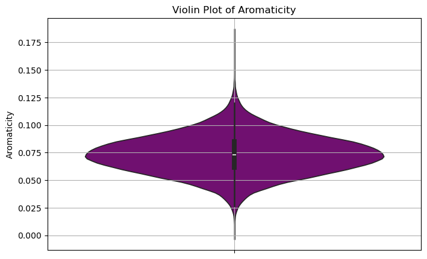

[5 more figures not shown]

```python
Num_Col = protein_df.select_dtypes(include=['int64','float64']).columns
for col in Num_Col:
    plt.figure(figsize=(8, 5))
    sns.violinplot(y=protein_df[col], color='purple')
    plt.title(f'Violin Plot of {col}')
    plt.ylabel(col)
    plt.grid(True)
    plt.show()
```